# How Far Can the Jackstraw Scale?

```r
knitr::opts_chunk$set(
  collapse  = TRUE,
  comment   = "#>",
  fig.width = 7,
  fig.height = 4,
  message   = FALSE,
  warning   = FALSE
)
run_heavy <- identical(Sys.getenv("RAJIVEPLUS_VIGNETTE_HEAVY"), "1")
data_dir  <- "data"
```

## The question

After RaJIVE finds a joint axis, the next question is more local: which features are actually tied to it? `jackstraw_rajive()` answers with a score-permutation approximation. It samples feature rows, permutes the joint score to break the association expected under the null, and compares observed F-statistics with the accumulated null statistics.

The cost has three moving parts:

- **n** (samples): more rows increase the linear algebra cost
- **p** (features per block): more observed F-statistics are scored
- **n_null** (null replicates): the user-controlled accuracy/cost dial

This vignette asks how those three parts behave in practice, then turns the timings into a rule of thumb for choosing `n_null`.

All timing and memory runs use the current default multiple-testing behavior, `correction = "BH"` (Benjamini-Hochberg), applied globally across all block/component/feature tests in each run. Use `correction = "BY"` when you want the more conservative Benjamini-Yekutieli procedure under arbitrary feature dependence.

## Setup

```r
library(rajiveplus)
library(peakRAM)
library(ggplot2)
```

## Time vs Sample Size (n)

```r
ns <- c(50L, 100L, 200L)

time_n_rows <- lapply(ns, function(n_i) {
  set.seed(42)
  Y_i    <- ajive.data.sim(K = 2, rankJ = 2, rankA = c(5, 5),
                           n = n_i, pks = c(500, 500))
  blks_i <- Y_i$sim_data
  fit_i  <- Rajive(blks_i, c(5, 5), joint_rank = 2L,
                   num_cores = 2L, seed = 42L)
  t_i    <- system.time(
    jackstraw_rajive(fit_i, blks_i, n_null = 10L)
  )["elapsed"]
  data.frame(n = n_i, elapsed = t_i)
})
time_n_df <- do.call(rbind, time_n_rows)
saveRDS(time_n_df, file.path(data_dir, "jackstraw_time_vs_n.rds"))
```

```r
time_n_df <- readRDS(file.path(data_dir, "jackstraw_time_vs_n.rds"))
knitr::kable(time_n_df,
             col.names = c("n (samples)", "Elapsed (s)"),
             digits = 1,
             caption = "jackstraw_rajive() elapsed time vs sample size (p=500, n_null=10)")
```

jackstraw_rajive() elapsed time vs sample size (p=500, n_null=10)

|  | n (samples) | Elapsed (s) |
| --- | --- | --- |
| elapsed | 50 | 0.1 |
| elapsed1 | 100 | 0.1 |
| elapsed2 | 200 | 0.1 |

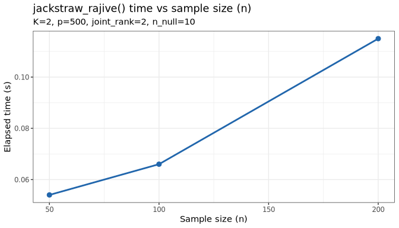

```r
ggplot(time_n_df, aes(x = n, y = elapsed)) +
  geom_line(colour = "#2166ac", linewidth = 1) +
  geom_point(size = 2.5, colour = "#2166ac") +
  labs(title    = "jackstraw_rajive() time vs sample size (n)",
       subtitle = "K=2, p=500, joint_rank=2, n_null=10",
       x = "Sample size (n)", y = "Elapsed time (s)") +
  theme_bw()
```

## Time vs Feature Count (p)

```r
ps <- c(100L, 500L, 1000L, 2000L)

time_p_rows <- lapply(ps, function(p_i) {
  set.seed(42)
  Y_i    <- ajive.data.sim(K = 2, rankJ = 2, rankA = c(5, 5),
                           n = 100, pks = c(p_i, p_i))
  blks_i <- Y_i$sim_data
  fit_i  <- Rajive(blks_i, c(5, 5), joint_rank = 2L,
                   num_cores = 2L, seed = 42L)
  t_i    <- system.time(
    jackstraw_rajive(fit_i, blks_i, n_null = 10L)
  )["elapsed"]
  data.frame(p = p_i, elapsed = t_i)
})
time_p_df <- do.call(rbind, time_p_rows)
saveRDS(time_p_df, file.path(data_dir, "jackstraw_time_vs_p.rds"))
```

```r
time_p_df <- readRDS(file.path(data_dir, "jackstraw_time_vs_p.rds"))
knitr::kable(time_p_df,
             col.names = c("p (features)", "Elapsed (s)"),
             digits = 1,
             caption = "jackstraw_rajive() elapsed time vs feature count (n=100, n_null=10)")
```

jackstraw_rajive() elapsed time vs feature count (n=100, n_null=10)

|  | p (features) | Elapsed (s) |
| --- | --- | --- |
| elapsed | 100 | 0.0 |
| elapsed1 | 500 | 0.1 |
| elapsed2 | 1000 | 0.1 |
| elapsed3 | 2000 | 0.3 |

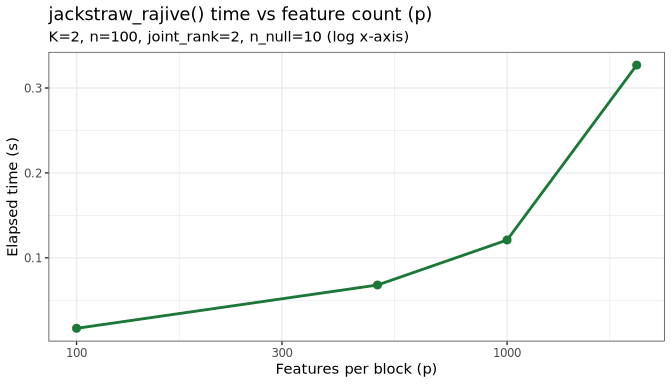

```r
ggplot(time_p_df, aes(x = p, y = elapsed)) +
  geom_line(colour = "#1b7837", linewidth = 1) +
  geom_point(size = 2.5, colour = "#1b7837") +
  scale_x_log10() +
  labs(title    = "jackstraw_rajive() time vs feature count (p)",
       subtitle = "K=2, n=100, joint_rank=2, n_null=10 (log x-axis)",
       x = "Features per block (p)", y = "Elapsed time (s)") +
  theme_bw()
```

## Time vs n_null

`n_null` is the knob analysts actually turn. Because the permutation loop runs once per null replicate, the elapsed time should rise almost linearly.

```r
nnulls <- c(5L, 10L, 25L, 50L)

set.seed(42)
Y_base    <- ajive.data.sim(K = 2, rankJ = 2, rankA = c(5, 5),
                             n = 100, pks = c(500, 500))
blks_base <- Y_base$sim_data
fit_base  <- Rajive(blks_base, c(5, 5), joint_rank = 2L,
                    num_cores = 2L, seed = 42L)

time_nnull_rows <- lapply(nnulls, function(nn) {
  t_i <- system.time(
    jackstraw_rajive(fit_base, blks_base, n_null = nn)
  )["elapsed"]
  data.frame(n_null = nn, elapsed = t_i)
})
time_nnull_df <- do.call(rbind, time_nnull_rows)
saveRDS(time_nnull_df, file.path(data_dir, "jackstraw_time_vs_nnull.rds"))
```

```r
time_nnull_df <- readRDS(file.path(data_dir, "jackstraw_time_vs_nnull.rds"))
knitr::kable(time_nnull_df,
             col.names = c("n_null", "Elapsed (s)"),
             digits = 1,
             caption = "jackstraw_rajive() elapsed time vs n_null (n=100, p=500)")
```

jackstraw_rajive() elapsed time vs n_null (n=100, p=500)

|  | n_null | Elapsed (s) |
| --- | --- | --- |
| elapsed | 5 | 0.0 |
| elapsed1 | 10 | 0.1 |
| elapsed2 | 25 | 0.1 |
| elapsed3 | 50 | 0.3 |

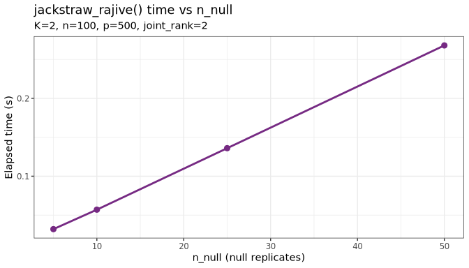

```r
ggplot(time_nnull_df, aes(x = n_null, y = elapsed)) +
  geom_line(colour = "#762a83", linewidth = 1) +
  geom_point(size = 2.5, colour = "#762a83") +
  labs(title    = "jackstraw_rajive() time vs n_null",
       subtitle = "K=2, n=100, p=500, joint_rank=2",
       x = "n_null (null replicates)", y = "Elapsed time (s)") +
  theme_bw()
```

## Memory (peakRAM)

```r
ram_n_rows <- lapply(c(50L, 100L, 200L), function(n_i) {
  set.seed(42)
  Y_i    <- ajive.data.sim(K = 2, rankJ = 2, rankA = c(5, 5),
                           n = n_i, pks = c(500, 500))
  blks_i <- Y_i$sim_data
  fit_i  <- Rajive(blks_i, c(5, 5), joint_rank = 2L,
                   num_cores = 2L, seed = 42L)
  mem_i  <- peakRAM::peakRAM(jackstraw_rajive(fit_i, blks_i, n_null = 10L))
  data.frame(n = n_i, peak_ram_mb = mem_i$Peak_RAM_Used_MiB)
})
ram_n_df <- do.call(rbind, ram_n_rows)
saveRDS(ram_n_df, file.path(data_dir, "jackstraw_ram_vs_n.rds"))
```

```r
ram_p_rows <- lapply(c(100L, 500L, 1000L, 2000L), function(p_i) {
  set.seed(42)
  Y_i    <- ajive.data.sim(K = 2, rankJ = 2, rankA = c(5, 5),
                           n = 100, pks = c(p_i, p_i))
  blks_i <- Y_i$sim_data
  fit_i  <- Rajive(blks_i, c(5, 5), joint_rank = 2L,
                   num_cores = 2L, seed = 42L)
  mem_i  <- peakRAM::peakRAM(jackstraw_rajive(fit_i, blks_i, n_null = 10L))
  data.frame(p = p_i, peak_ram_mb = mem_i$Peak_RAM_Used_MiB)
})
ram_p_df <- do.call(rbind, ram_p_rows)
saveRDS(ram_p_df, file.path(data_dir, "jackstraw_ram_vs_p.rds"))
```

```r
ram_n_df <- readRDS(file.path(data_dir, "jackstraw_ram_vs_n.rds"))
ram_p_df <- readRDS(file.path(data_dir, "jackstraw_ram_vs_p.rds"))
```

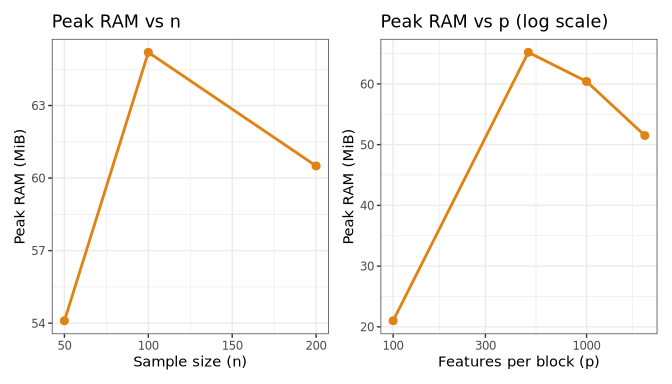

```r
p_ram_n <- ggplot(ram_n_df, aes(x = n, y = peak_ram_mb)) +
  geom_line(colour = "#e08214", linewidth = 1) +
  geom_point(size = 2.5, colour = "#e08214") +
  labs(title = "Peak RAM vs n", x = "Sample size (n)", y = "Peak RAM (MiB)") +
  theme_bw()

p_ram_p <- ggplot(ram_p_df, aes(x = p, y = peak_ram_mb)) +
  geom_line(colour = "#e08214", linewidth = 1) +
  geom_point(size = 2.5, colour = "#e08214") +
  scale_x_log10() +
  labs(title = "Peak RAM vs p (log scale)", x = "Features per block (p)", y = "Peak RAM (MiB)") +
  theme_bw()

if (requireNamespace("patchwork", quietly = TRUE)) {
  print(patchwork::wrap_plots(p_ram_n, p_ram_p, ncol = 2))
} else {
  print(p_ram_n); print(p_ram_p)
}
```

## profmem: allocation profile on small data

On tiny data (`n = 50`, `p = 100`), `profmem` can show which R call stacks allocate most of the R heap while still running quickly in the vignette.

```r
if (requireNamespace("profmem", quietly = TRUE)) {
  set.seed(1)
  Y_tiny    <- ajive.data.sim(K = 2, rankJ = 2, rankA = c(3, 3),
                               n = 50, pks = c(100, 100))
  blks_tiny <- Y_tiny$sim_data
  fit_tiny  <- Rajive(blks_tiny, c(3, 3), joint_rank = 2L,
                      num_cores = 1L, seed = 42L)

  pm <- profmem::profmem(jackstraw_rajive(fit_tiny, blks_tiny, n_null = 5L))

  # Top 10 allocating calls by total bytes
  pm_df <- as.data.frame(pm)
  pm_df <- pm_df[!is.na(pm_df$bytes), ]
  pm_agg <- aggregate(bytes ~ calls, data = pm_df, FUN = sum)
  pm_top <- pm_agg[order(-pm_agg$bytes)[1:min(10, nrow(pm_agg))], ]
  pm_top$MB <- round(pm_top$bytes / 1024^2, 2)
  knitr::kable(pm_top[, c("calls", "MB")],
               row.names = FALSE,
               col.names = c("Call stack (truncated)", "Allocated (MiB)"),
               caption   = "Top 10 allocating call stacks in jackstraw_rajive() (n=50, p=100, n_null=5)")
} else {
  message("profmem not installed; skipping allocation profile")
}
```

Top 10 allocating call stacks in jackstraw_rajive() (n=50, p=100, n_null=5)

| Call stack (truncated) | Allocated (MiB) |
| --- | --- |
| jackstraw_rajive() -> generate_null_f_stats() -> .ols_f_stat_from_centered() | 0.47 |
|  | 0.14 |
| jackstraw_rajive() -> ols_f_stat_matrix() | 0.12 |
| jackstraw_rajive() -> generate_null_f_stats() | 0.11 |
| jackstraw_rajive() | 0.11 |
| jackstraw_rajive() -> generate_null_f_stats() -> rowSums() -> is.data.frame() | 0.08 |
| jackstraw_rajive() -> ols_f_stat_matrix() -> rowSums() -> is.data.frame() | 0.08 |
| jackstraw_rajive() -> t() -> t.default() | 0.08 |
| jackstraw_rajive() -> compute_empirical_pvalues() | 0.03 |
| jackstraw_rajive() -> ols_f_stat_matrix() -> mean() -> get() | 0.02 |

## profvis: interactive profile

`profvis` is best used at the console because it returns an HTML widget rather than a static plot. The code below is kept as a ready-made flame-graph recipe.

```r
# Run interactively only — not rendered in the vignette
if (requireNamespace("profvis", quietly = TRUE)) {
  set.seed(1)
  Y_pv  <- ajive.data.sim(K = 2, rankJ = 2, rankA = c(5, 5),
                           n = 100, pks = c(500, 500))
  blks_pv <- Y_pv$sim_data
  fit_pv  <- Rajive(blks_pv, c(5, 5), joint_rank = 2L,
                    num_cores = 2L, seed = 42L)
  profvis::profvis(jackstraw_rajive(fit_pv, blks_pv, n_null = 10L))
}
```

## Four views of the same cost

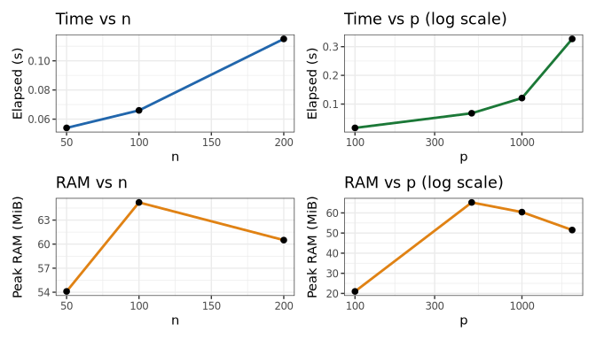

```r
time_n_df  <- readRDS(file.path(data_dir, "jackstraw_time_vs_n.rds"))
time_p_df  <- readRDS(file.path(data_dir, "jackstraw_time_vs_p.rds"))
ram_n_df   <- readRDS(file.path(data_dir, "jackstraw_ram_vs_n.rds"))
ram_p_df   <- readRDS(file.path(data_dir, "jackstraw_ram_vs_p.rds"))

p_tn <- ggplot(time_n_df, aes(n, elapsed)) +
  geom_line(colour = "#2166ac", linewidth = 1) + geom_point(size = 2) +
  labs(title = "Time vs n", x = "n", y = "Elapsed (s)") + theme_bw()

p_tp <- ggplot(time_p_df, aes(p, elapsed)) +
  geom_line(colour = "#1b7837", linewidth = 1) + geom_point(size = 2) +
  scale_x_log10() +
  labs(title = "Time vs p (log scale)", x = "p", y = "Elapsed (s)") + theme_bw()

p_rn <- ggplot(ram_n_df, aes(n, peak_ram_mb)) +
  geom_line(colour = "#e08214", linewidth = 1) + geom_point(size = 2) +
  labs(title = "RAM vs n", x = "n", y = "Peak RAM (MiB)") + theme_bw()

p_rp <- ggplot(ram_p_df, aes(p, peak_ram_mb)) +
  geom_line(colour = "#e08214", linewidth = 1) + geom_point(size = 2) +
  scale_x_log10() +
  labs(title = "RAM vs p (log scale)", x = "p", y = "Peak RAM (MiB)") + theme_bw()

if (requireNamespace("patchwork", quietly = TRUE)) {
  print(patchwork::wrap_plots(p_tn, p_tp, p_rn, p_rp, ncol = 2))
} else {
  print(p_tn); print(p_tp); print(p_rn); print(p_rp)
}
```

## Choosing n_null

```r
guide_df <- data.frame(
  Dataset_size = c(
    "Small (n<100, p<500)",
    "Medium (n=100-300, p=500-2000)",
    "Large (n>300, p>2000)",
    "CLL-scale (n~150, p~500 per block)"
  ),
  Recommended_n_null = c("100", "25-50", "10-25", "50"),
  Expected_time      = c("<5 min", "5-20 min", "20-60 min", "~60 min"),
  Note               = c(
    "Stable p-values with 100 replicates",
    "Good power/cost tradeoff",
    "Use n_null=10 for exploration, increase for final results",
    "Used in cll_application vignette"
  )
)
knitr::kable(guide_df,
             col.names = c("Dataset size", "n_null", "Expected time", "Note"),
             caption   = "Practical n_null recommendations for jackstraw_rajive()")
```

Practical n_null recommendations for jackstraw_rajive()

[output not shown]

The practical pattern is simple: start small, learn the signal, then spend the replicates where it matters. Because `n_null` scales nearly linearly, an exploratory run at `n_null = 10` is cheap insurance before increasing to 50-100 for the final analysis.